# Risk Factor Analysis

## Outcome Variable

**Outcome Variable:** co_occurence

## Predictor Variables

**Intervention Variable:** ever_sunderweight06

**Adjustment Set:**

- sex
- arm
- brthmon
- single
- hhwealth_quart
- W_mage
- W_mhtcm
- W_meducyrs
- W_feducyrs
- delta_brthmon
- delta_single
- delta_hhwealth_quart
- delta_W_mage
- delta_W_mhtcm
- delta_W_meducyrs
- delta_W_feducyrs

## Stratifying Variables

The analysis was stratified on these variable(s):

- studyid
- country

## Data Summary

| studyid | country | ever_sunderweight06 | co_occurence | n_cell | n |
| --- | --- | --- | --- | --- | --- |
| ki0047075b-MAL-ED | BANGLADESH | 0 | 0 | 196 | 221 |
| ki0047075b-MAL-ED | BANGLADESH | 0 | 1 | 11 | 221 |
| ki0047075b-MAL-ED | BANGLADESH | 1 | 0 | 11 | 221 |
| ki0047075b-MAL-ED | BANGLADESH | 1 | 1 | 3 | 221 |
| ki0047075b-MAL-ED | BRAZIL | 0 | 0 | 176 | 180 |
| ki0047075b-MAL-ED | BRAZIL | 0 | 1 | 1 | 180 |
| ki0047075b-MAL-ED | BRAZIL | 1 | 0 | 3 | 180 |
| ki0047075b-MAL-ED | BRAZIL | 1 | 1 | 0 | 180 |
| ki0047075b-MAL-ED | INDIA | 0 | 0 | 187 | 228 |
| ki0047075b-MAL-ED | INDIA | 0 | 1 | 10 | 228 |
| ki0047075b-MAL-ED | INDIA | 1 | 0 | 24 | 228 |
| ki0047075b-MAL-ED | INDIA | 1 | 1 | 7 | 228 |
| ki0047075b-MAL-ED | NEPAL | 0 | 0 | 215 | 229 |
| ki0047075b-MAL-ED | NEPAL | 0 | 1 | 2 | 229 |
| ki0047075b-MAL-ED | NEPAL | 1 | 0 | 10 | 229 |
| ki0047075b-MAL-ED | NEPAL | 1 | 1 | 2 | 229 |
| ki0047075b-MAL-ED | PERU | 0 | 0 | 210 | 222 |
| ki0047075b-MAL-ED | PERU | 0 | 1 | 4 | 222 |
| ki0047075b-MAL-ED | PERU | 1 | 0 | 6 | 222 |
| ki0047075b-MAL-ED | PERU | 1 | 1 | 2 | 222 |
| ki0047075b-MAL-ED | SOUTH AFRICA | 0 | 0 | 227 | 241 |
| ki0047075b-MAL-ED | SOUTH AFRICA | 0 | 1 | 3 | 241 |
| ki0047075b-MAL-ED | SOUTH AFRICA | 1 | 0 | 10 | 241 |
| ki0047075b-MAL-ED | SOUTH AFRICA | 1 | 1 | 1 | 241 |
| ki0047075b-MAL-ED | TANZANIA, UNITED REPUBLIC OF | 0 | 0 | 217 | 225 |
| ki0047075b-MAL-ED | TANZANIA, UNITED REPUBLIC OF | 0 | 1 | 0 | 225 |
| ki0047075b-MAL-ED | TANZANIA, UNITED REPUBLIC OF | 1 | 0 | 7 | 225 |
| ki0047075b-MAL-ED | TANZANIA, UNITED REPUBLIC OF | 1 | 1 | 1 | 225 |
| ki1000108-CMC-V-BCS-2002 | INDIA | 0 | 0 | 286 | 369 |
| ki1000108-CMC-V-BCS-2002 | INDIA | 0 | 1 | 8 | 369 |

[output cut: 78 more lines]

The following strata were considered:

- studyid: ki0047075b-MAL-ED, country: BANGLADESH
- studyid: ki0047075b-MAL-ED, country: BRAZIL
- studyid: ki0047075b-MAL-ED, country: INDIA
- studyid: ki0047075b-MAL-ED, country: NEPAL
- studyid: ki0047075b-MAL-ED, country: PERU
- studyid: ki0047075b-MAL-ED, country: SOUTH AFRICA
- studyid: ki0047075b-MAL-ED, country: TANZANIA, UNITED REPUBLIC OF
- studyid: ki1000108-CMC-V-BCS-2002, country: INDIA
- studyid: ki1000108-IRC, country: INDIA
- studyid: ki1000109-EE, country: PAKISTAN
- studyid: ki1000109-ResPak, country: PAKISTAN
- studyid: ki1000304b-SAS-CompFeed, country: INDIA
- studyid: ki1000304b-SAS-FoodSuppl, country: INDIA
- studyid: ki1017093-NIH-Birth, country: BANGLADESH
- studyid: ki1017093b-PROVIDE, country: BANGLADESH
- studyid: ki1017093c-NIH-Crypto, country: BANGLADESH
- studyid: ki1066203-TanzaniaChild2, country: TANZANIA, UNITED REPUBLIC OF
- studyid: ki1101329-Keneba, country: GAMBIA
- studyid: ki1113344-GMS-Nepal, country: NEPAL
- studyid: ki1114097-CMIN, country: BANGLADESH
- studyid: ki1114097-CONTENT, country: PERU
- studyid: ki1119695-PROBIT, country: BELARUS
- studyid: ki1126311-ZVITAMBO, country: ZIMBABWE
- studyid: ki1135781-COHORTS, country: GUATEMALA
- studyid: ki1135781-COHORTS, country: PHILIPPINES
- studyid: ki1148112-LCNI-5, country: MALAWI
- studyid: kiGH5241-JiVitA-4, country: BANGLADESH

### Dropped Strata

Some strata were dropped due to rare outcomes:

- studyid: ki0047075b-MAL-ED, country: BANGLADESH
- studyid: ki0047075b-MAL-ED, country: BRAZIL
- studyid: ki0047075b-MAL-ED, country: NEPAL
- studyid: ki0047075b-MAL-ED, country: PERU
- studyid: ki0047075b-MAL-ED, country: SOUTH AFRICA
- studyid: ki0047075b-MAL-ED, country: TANZANIA, UNITED REPUBLIC OF
- studyid: ki1000109-ResPak, country: PAKISTAN
- studyid: ki1066203-TanzaniaChild2, country: TANZANIA, UNITED REPUBLIC OF
- studyid: ki1114097-CONTENT, country: PERU
- studyid: ki1119695-PROBIT, country: BELARUS
- studyid: ki1148112-LCNI-5, country: MALAWI

## Methods Detail

We’re interested in the causal parameters $E[Y_a]$ for all values of $a \in \mathcal{A}$. These parameters represent the mean outcome if, possibly contrary to fact, we intervened to set all units to have $A=a$. Under the randomization and positivity assumptions, these are identified by the statistical parameters $\psi_a=E_W[E_{Y|A,W}(Y|A=a,W)]$. In addition, we’re interested in the mean of $Y$, $E[Y]$ under no intervention (the observed mean). We will estimate these parameters by using SuperLearner to fit the relevant likelihood factors – $E_{Y|A,W}(Y|A=a,W)$ and $p(A=a|W)$, and then updating our likelihood fit using a joint TMLE.

For unadjusted analyses ($W=\{\}$), initial likelihoods were estimated using Lrnr_glm to estimate the simple $E(Y|A)$ and Lrnr_mean to estimate $p(A)$. For adjusted analyses, a small library containing Lrnr_glmnet, Lrnr_xgboost, and Lrnr_mean was used.

Having estimated these parameters, we will then use the delta method to estimate relative risks and attributable risks relative to a prespecified baseline level of $A$.

# Results Detail

## Results Plots

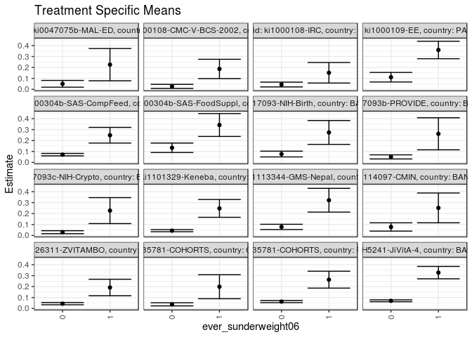

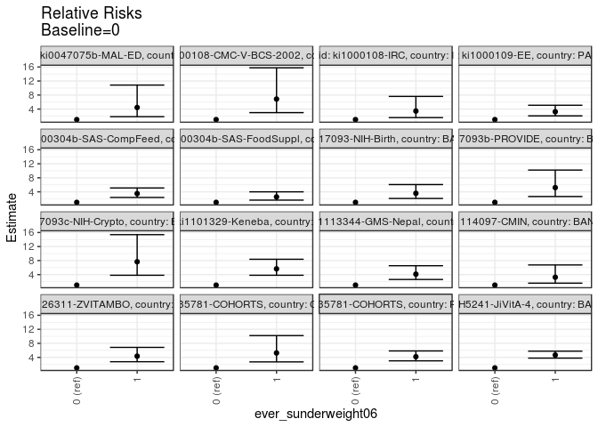

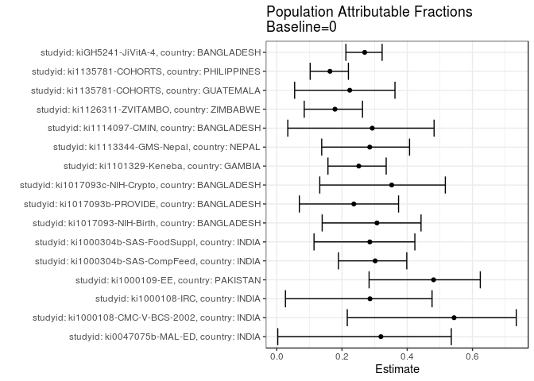

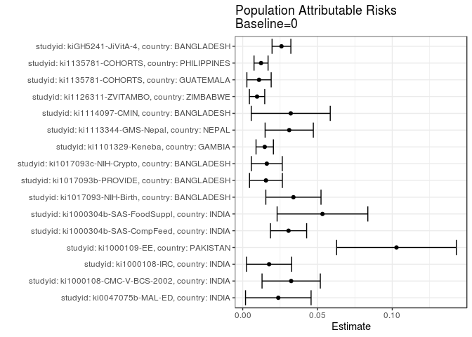

## Results Table

### Parameter: TSM

| studyid | country | intervention_level | baseline_level | estimate | ci_lower | ci_upper |
| --- | --- | --- | --- | --- | --- | --- |
| ki0047075b-MAL-ED | INDIA | 0 | NA | 0.0507614 | 0.0200412 | 0.0814816 |
| ki0047075b-MAL-ED | INDIA | 1 | NA | 0.2258065 | 0.0782988 | 0.3733141 |
| ki1000108-CMC-V-BCS-2002 | INDIA | 0 | NA | 0.0272109 | 0.0085881 | 0.0458337 |
| ki1000108-CMC-V-BCS-2002 | INDIA | 1 | NA | 0.1866667 | 0.0983639 | 0.2749695 |
| ki1000108-IRC | INDIA | 0 | NA | 0.0440790 | 0.0222864 | 0.0658716 |
| ki1000108-IRC | INDIA | 1 | NA | 0.1517135 | 0.0579941 | 0.2454328 |
| ki1000109-EE | PAKISTAN | 0 | NA | 0.1110455 | 0.0673070 | 0.1547841 |
| ki1000109-EE | PAKISTAN | 1 | NA | 0.3598716 | 0.2801209 | 0.4396223 |
| ki1000304b-SAS-CompFeed | INDIA | 0 | NA | 0.0709384 | 0.0598083 | 0.0820685 |
| ki1000304b-SAS-CompFeed | INDIA | 1 | NA | 0.2483649 | 0.1768537 | 0.3198762 |
| ki1000304b-SAS-FoodSuppl | INDIA | 0 | NA | 0.1335744 | 0.0902108 | 0.1769380 |
| ki1000304b-SAS-FoodSuppl | INDIA | 1 | NA | 0.3417200 | 0.2371524 | 0.4462876 |
| ki1017093-NIH-Birth | BANGLADESH | 0 | NA | 0.0764780 | 0.0501010 | 0.1028550 |
| ki1017093-NIH-Birth | BANGLADESH | 1 | NA | 0.2736847 | 0.1647151 | 0.3826544 |
| ki1017093b-PROVIDE | BANGLADESH | 0 | NA | 0.0501864 | 0.0315356 | 0.0688371 |
| ki1017093b-PROVIDE | BANGLADESH | 1 | NA | 0.2613846 | 0.1149184 | 0.4078507 |
| ki1017093c-NIH-Crypto | BANGLADESH | 0 | NA | 0.0296242 | 0.0158959 | 0.0433524 |
| ki1017093c-NIH-Crypto | BANGLADESH | 1 | NA | 0.2270025 | 0.1083698 | 0.3456352 |
| ki1101329-Keneba | GAMBIA | 0 | NA | 0.0437891 | 0.0341561 | 0.0534220 |
| ki1101329-Keneba | GAMBIA | 1 | NA | 0.2471952 | 0.1658758 | 0.3285145 |
| ki1113344-GMS-Nepal | NEPAL | 0 | NA | 0.0779917 | 0.0538570 | 0.1021264 |
| ki1113344-GMS-Nepal | NEPAL | 1 | NA | 0.3218673 | 0.2133479 | 0.4303868 |
| ki1114097-CMIN | BANGLADESH | 0 | NA | 0.0775832 | 0.0396441 | 0.1155223 |
| ki1114097-CMIN | BANGLADESH | 1 | NA | 0.2517224 | 0.1155439 | 0.3879010 |
| ki1126311-ZVITAMBO | ZIMBABWE | 0 | NA | 0.0441825 | 0.0340483 | 0.0543167 |
| ki1126311-ZVITAMBO | ZIMBABWE | 1 | NA | 0.1918739 | 0.1163413 | 0.2674065 |
| ki1135781-COHORTS | GUATEMALA | 0 | NA | 0.0378661 | 0.0238281 | 0.0519041 |
| ki1135781-COHORTS | GUATEMALA | 1 | NA | 0.1989326 | 0.0893190 | 0.3085462 |
| ki1135781-COHORTS | PHILIPPINES | 0 | NA | 0.0629215 | 0.0531366 | 0.0727064 |
| ki1135781-COHORTS | PHILIPPINES | 1 | NA | 0.2632996 | 0.1860950 | 0.3405043 |
| kiGH5241-JiVitA-4 | BANGLADESH | 0 | NA | 0.0701919 | 0.0617078 | 0.0786760 |
| kiGH5241-JiVitA-4 | BANGLADESH | 1 | NA | 0.3277921 | 0.2711560 | 0.3844281 |

### Parameter: E(Y)

| studyid | country | intervention_level | baseline_level | estimate | ci_lower | ci_upper |
| --- | --- | --- | --- | --- | --- | --- |
| ki0047075b-MAL-ED | INDIA | NA | NA | 0.0745614 | 0.0403897 | 0.1087331 |
| ki1000108-CMC-V-BCS-2002 | INDIA | NA | NA | 0.0596206 | 0.0354285 | 0.0838127 |
| ki1000108-IRC | INDIA | NA | NA | 0.0617284 | 0.0382610 | 0.0851958 |
| ki1000109-EE | PAKISTAN | NA | NA | 0.2138728 | 0.1706052 | 0.2571404 |
| ki1000304b-SAS-CompFeed | INDIA | NA | NA | 0.1015873 | 0.0902183 | 0.1129563 |
| ki1000304b-SAS-FoodSuppl | INDIA | NA | NA | 0.1869159 | 0.1442025 | 0.2296293 |
| ki1017093-NIH-Birth | BANGLADESH | NA | NA | 0.1103896 | 0.0817833 | 0.1389959 |
| ki1017093b-PROVIDE | BANGLADESH | NA | NA | 0.0657194 | 0.0452330 | 0.0862057 |
| ki1017093c-NIH-Crypto | BANGLADESH | NA | NA | 0.0457413 | 0.0294659 | 0.0620168 |
| ki1101329-Keneba | GAMBIA | NA | NA | 0.0585078 | 0.0478474 | 0.0691682 |
| ki1113344-GMS-Nepal | NEPAL | NA | NA | 0.1090909 | 0.0830130 | 0.1351688 |
| ki1114097-CMIN | BANGLADESH | NA | NA | 0.1097046 | 0.0698323 | 0.1495770 |
| ki1126311-ZVITAMBO | ZIMBABWE | NA | NA | 0.0537825 | 0.0430304 | 0.0645346 |
| ki1135781-COHORTS | GUATEMALA | NA | NA | 0.0487805 | 0.0336441 | 0.0639169 |
| ki1135781-COHORTS | PHILIPPINES | NA | NA | 0.0751910 | 0.0648251 | 0.0855569 |
| kiGH5241-JiVitA-4 | BANGLADESH | NA | NA | 0.0961073 | 0.0860713 | 0.1061434 |

### Parameter: RR

| studyid | country | intervention_level | baseline_level | estimate | ci_lower | ci_upper |
| --- | --- | --- | --- | --- | --- | --- |
| ki0047075b-MAL-ED | INDIA | 0 | 0 | 1.000000 | 1.000000 | 1.000000 |
| ki0047075b-MAL-ED | INDIA | 1 | 0 | 4.448387 | 1.825847 | 10.837790 |
| ki1000108-CMC-V-BCS-2002 | INDIA | 0 | 0 | 1.000000 | 1.000000 | 1.000000 |
| ki1000108-CMC-V-BCS-2002 | INDIA | 1 | 0 | 6.860000 | 2.985432 | 15.763079 |
| ki1000108-IRC | INDIA | 0 | 0 | 1.000000 | 1.000000 | 1.000000 |
| ki1000108-IRC | INDIA | 1 | 0 | 3.441855 | 1.555706 | 7.614783 |
| ki1000109-EE | PAKISTAN | 0 | 0 | 1.000000 | 1.000000 | 1.000000 |
| ki1000109-EE | PAKISTAN | 1 | 0 | 3.240758 | 2.060835 | 5.096239 |
| ki1000304b-SAS-CompFeed | INDIA | 0 | 0 | 1.000000 | 1.000000 | 1.000000 |
| ki1000304b-SAS-CompFeed | INDIA | 1 | 0 | 3.501136 | 2.402812 | 5.101503 |
| ki1000304b-SAS-FoodSuppl | INDIA | 0 | 0 | 1.000000 | 1.000000 | 1.000000 |
| ki1000304b-SAS-FoodSuppl | INDIA | 1 | 0 | 2.558275 | 1.636291 | 3.999759 |
| ki1017093-NIH-Birth | BANGLADESH | 0 | 0 | 1.000000 | 1.000000 | 1.000000 |
| ki1017093-NIH-Birth | BANGLADESH | 1 | 0 | 3.578606 | 2.108371 | 6.074084 |
| ki1017093b-PROVIDE | BANGLADESH | 0 | 0 | 1.000000 | 1.000000 | 1.000000 |
| ki1017093b-PROVIDE | BANGLADESH | 1 | 0 | 5.208280 | 2.658263 | 10.204474 |
| ki1017093c-NIH-Crypto | BANGLADESH | 0 | 0 | 1.000000 | 1.000000 | 1.000000 |
| ki1017093c-NIH-Crypto | BANGLADESH | 1 | 0 | 7.662744 | 3.813918 | 15.395622 |
| ki1101329-Keneba | GAMBIA | 0 | 0 | 1.000000 | 1.000000 | 1.000000 |
| ki1101329-Keneba | GAMBIA | 1 | 0 | 5.645135 | 3.805481 | 8.374120 |
| ki1113344-GMS-Nepal | NEPAL | 0 | 0 | 1.000000 | 1.000000 | 1.000000 |
| ki1113344-GMS-Nepal | NEPAL | 1 | 0 | 4.126943 | 2.608107 | 6.530275 |
| ki1114097-CMIN | BANGLADESH | 0 | 0 | 1.000000 | 1.000000 | 1.000000 |
| ki1114097-CMIN | BANGLADESH | 1 | 0 | 3.244549 | 1.560485 | 6.746043 |
| ki1126311-ZVITAMBO | ZIMBABWE | 0 | 0 | 1.000000 | 1.000000 | 1.000000 |
| ki1126311-ZVITAMBO | ZIMBABWE | 1 | 0 | 4.342755 | 2.753110 | 6.850259 |
| ki1135781-COHORTS | GUATEMALA | 0 | 0 | 1.000000 | 1.000000 | 1.000000 |
| ki1135781-COHORTS | GUATEMALA | 1 | 0 | 5.253578 | 2.703597 | 10.208653 |
| ki1135781-COHORTS | PHILIPPINES | 0 | 0 | 1.000000 | 1.000000 | 1.000000 |
| ki1135781-COHORTS | PHILIPPINES | 1 | 0 | 4.184574 | 3.003690 | 5.829718 |
| kiGH5241-JiVitA-4 | BANGLADESH | 0 | 0 | 1.000000 | 1.000000 | 1.000000 |
| kiGH5241-JiVitA-4 | BANGLADESH | 1 | 0 | 4.669942 | 3.786641 | 5.759287 |

### Parameter: PAR

| studyid | country | intervention_level | baseline_level | estimate | ci_lower | ci_upper |
| --- | --- | --- | --- | --- | --- | --- |
| ki0047075b-MAL-ED | INDIA | 0 | NA | 0.0238000 | 0.0018774 | 0.0457226 |
| ki1000108-CMC-V-BCS-2002 | INDIA | 0 | NA | 0.0324097 | 0.0129308 | 0.0518887 |
| ki1000108-IRC | INDIA | 0 | NA | 0.0176494 | 0.0025415 | 0.0327573 |
| ki1000109-EE | PAKISTAN | 0 | NA | 0.1028273 | 0.0628145 | 0.1428401 |
| ki1000304b-SAS-CompFeed | INDIA | 0 | NA | 0.0306489 | 0.0185479 | 0.0427500 |
| ki1000304b-SAS-FoodSuppl | INDIA | 0 | NA | 0.0533415 | 0.0230126 | 0.0836704 |
| ki1017093-NIH-Birth | BANGLADESH | 0 | NA | 0.0339116 | 0.0154632 | 0.0523600 |
| ki1017093b-PROVIDE | BANGLADESH | 0 | NA | 0.0155330 | 0.0045517 | 0.0265143 |
| ki1017093c-NIH-Crypto | BANGLADESH | 0 | NA | 0.0161171 | 0.0057696 | 0.0264647 |
| ki1101329-Keneba | GAMBIA | 0 | NA | 0.0147187 | 0.0089169 | 0.0205206 |
| ki1113344-GMS-Nepal | NEPAL | 0 | NA | 0.0310992 | 0.0149803 | 0.0472181 |
| ki1114097-CMIN | BANGLADESH | 0 | NA | 0.0321215 | 0.0057044 | 0.0585385 |
| ki1126311-ZVITAMBO | ZIMBABWE | 0 | NA | 0.0096000 | 0.0044708 | 0.0147291 |
| ki1135781-COHORTS | GUATEMALA | 0 | NA | 0.0109144 | 0.0027900 | 0.0190388 |
| ki1135781-COHORTS | PHILIPPINES | 0 | NA | 0.0122695 | 0.0075754 | 0.0169636 |
| kiGH5241-JiVitA-4 | BANGLADESH | 0 | NA | 0.0259154 | 0.0196319 | 0.0321989 |

### Parameter: PAF

| studyid | country | intervention_level | baseline_level | estimate | ci_lower | ci_upper |
| --- | --- | --- | --- | --- | --- | --- |
| ki0047075b-MAL-ED | INDIA | 0 | NA | 0.3191998 | 0.0031572 | 0.5350431 |
| ki1000108-CMC-V-BCS-2002 | INDIA | 0 | NA | 0.5435993 | 0.2162412 | 0.7342274 |
| ki1000108-IRC | INDIA | 0 | NA | 0.2859204 | 0.0267147 | 0.4760944 |
| ki1000109-EE | PAKISTAN | 0 | NA | 0.4807872 | 0.2830791 | 0.6239725 |
| ki1000304b-SAS-CompFeed | INDIA | 0 | NA | 0.3017002 | 0.1891365 | 0.3986379 |
| ki1000304b-SAS-FoodSuppl | INDIA | 0 | NA | 0.2853770 | 0.1142966 | 0.4234119 |
| ki1017093-NIH-Birth | BANGLADESH | 0 | NA | 0.3071991 | 0.1393223 | 0.4423311 |
| ki1017093b-PROVIDE | BANGLADESH | 0 | NA | 0.2363536 | 0.0693209 | 0.3734082 |
| ki1017093c-NIH-Crypto | BANGLADESH | 0 | NA | 0.3523542 | 0.1319310 | 0.5168068 |
| ki1101329-Keneba | GAMBIA | 0 | NA | 0.2515687 | 0.1570138 | 0.3355177 |
| ki1113344-GMS-Nepal | NEPAL | 0 | NA | 0.2850759 | 0.1378804 | 0.4071398 |
| ki1114097-CMIN | BANGLADESH | 0 | NA | 0.2927995 | 0.0338930 | 0.4823217 |
| ki1126311-ZVITAMBO | ZIMBABWE | 0 | NA | 0.1784961 | 0.0843230 | 0.2629839 |
| ki1135781-COHORTS | GUATEMALA | 0 | NA | 0.2237447 | 0.0549018 | 0.3624236 |
| ki1135781-COHORTS | PHILIPPINES | 0 | NA | 0.1631779 | 0.1025179 | 0.2197379 |
| kiGH5241-JiVitA-4 | BANGLADESH | 0 | NA | 0.2696509 | 0.2120319 | 0.3230566 |